# index

[figure not shown]

### Exercise 1

You will make two maps:

1. Plot your country as the background. Use **cx** to plot some **points** (the cities, airports, etc.) below the centroid.
2. Plot your country as the background. Select with **cx** all the first administrative divisions above the centroid. Then, use clip to show some **lines** (rivers, railroads, etc) that cross those divisions.

```python
import geopandas as gpd
countries=gpd.read_file('https://github.com/LeonarddoCLS/Avance-2/raw/refs/heads/main/World%20Country/World_Countries.shp')
argentina = countries[countries.COUNTRY=='Argentina']
centrales_electricas=gpd.read_file('https://github.com/LeonarddoCLS/Avance-2/raw/refs/heads/main/Energ%C3%ADa/puntos_de_energia_AD010Point.shp')
```

```python
argentina.crs
```

```
<Geographic 2D CRS: EPSG:4326>
Name: WGS 84
Axis Info [ellipsoidal]:
- Lat[north]: Geodetic latitude (degree)
- Lon[east]: Geodetic longitude (degree)
Area of Use:
- name: World.
- bounds: (-180.0, -90.0, 180.0, 90.0)
Datum: World Geodetic System 1984 ensemble
- Ellipsoid: WGS 84
- Prime Meridian: Greenwich
```

```python
argentina=argentina.to_crs(5343)
```

```python
argentina.total_bounds
```

```
array([1385481.70808148, 3884871.45452092, 3352642.62786363,
       7581252.17870236])
```

```python
argentina.centroid
```

|  | 0 |
| --- | --- |
| 10 | POINT (2166252.13 6144387.961) |

**dtype:** geometry

```python
centrales_electricas=centrales_electricas.to_crs(5343)
```

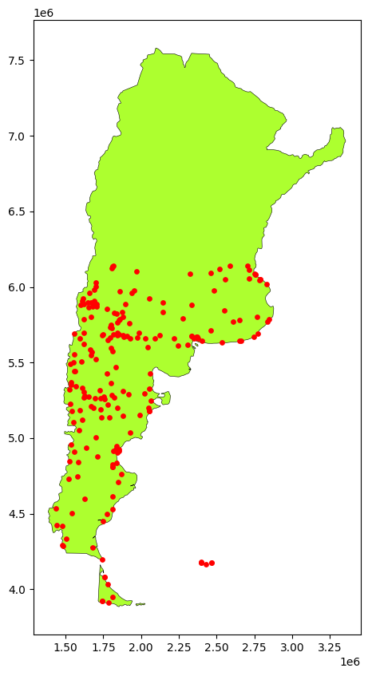

```python
base = argentina.plot(facecolor="greenyellow", edgecolor='black', linewidth=0.4, figsize=(10, 10))

centroid_lon = argentina.centroid.iloc[0].x
centroid_lat = argentina.centroid.iloc[0].y
centrales_abajo_centroid = centrales_electricas.cx[:, :centroid_lat]

centrales_abajo_centroid.plot(marker='o', color='red', markersize=15, ax=base)
```

Segundo apartado

```python
prov = gpd.read_file('https://github.com/LeonarddoCLS/Avance-2/raw/refs/heads/main/provincias/provinciaPolygon.shp')
ferrovias = gpd.read_file('https://github.com/LeonarddoCLS/Avance-2/raw/refs/heads/main/Ferroviales/lineas_de_transporte_ferroviario_AN010Line.shp')
```

```python
prov=prov.to_crs(5343)
ferrovias=ferrovias.to_crs(5343)
```

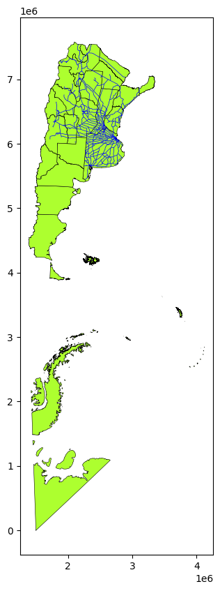

```python
base2 = prov.plot(facecolor="greenyellow", edgecolor='black', linewidth=0.4, figsize=(10, 10))
divisions_above_centroid = prov.cx[:, centroid_lat:]
clipped_ferrovias = gpd.clip(gdf=ferrovias, mask=divisions_above_centroid)
clipped_ferrovias.plot(edgecolor='blue', linewidth=0.5, ax=base2)
```

## Exercise 2

1. Create some subset of polygons with your country data at the municipal (or similar level). Use Unary UNION with those polygons, and create a geoDF with the result.

Con ayuda de cx.(o.O) Solo voy a unir el norte con el sur}

2. Dissolve your municipalities by another higher level administrative level. Plot the result.
3. If possible, color some areas of your country by aggregating; if not, plot the "median" values in the *indicators* map.

```python
import geopandas as gpd

provincias=gpd.read_file('https://github.com/LeonarddoCLS/Avance-2/raw/refs/heads/main/provincias/provinciaPolygon.shp')
```

```python
provincias.crs
```

```
<Geographic 2D CRS: EPSG:4326>
Name: WGS 84
Axis Info [ellipsoidal]:
- Lat[north]: Geodetic latitude (degree)
- Lon[east]: Geodetic longitude (degree)
Area of Use:
- name: World.
- bounds: (-180.0, -90.0, 180.0, 90.0)
Datum: World Geodetic System 1984 ensemble
- Ellipsoid: WGS 84
- Prime Meridian: Greenwich
```

```python
provincias=provincias.to_crs(5343)
```

```python
provincias.total_bounds
```

```
array([1.38772426e+06, 5.64183001e-01, 4.12249404e+06, 7.58120702e+06])
```

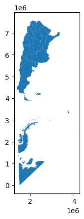

```python
provincias.plot()
```

## Unary UNION

We can combine all these polygons into one:

```python
!pip install shapely
```

```python
centroid_lat = provincias.centroid.iloc[0].y
prov_sur=provincias.cx[:,:centroid_lat]
```

```python
prov_norte = provincias.drop(prov_sur.index)
```

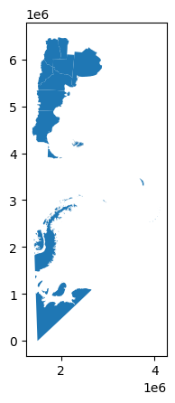

```python
prov_sur.plot()
```

**Propuesta**: Intersecar mis provincias con el border del world countries, para quitar a antartida y malvidas que fastidian

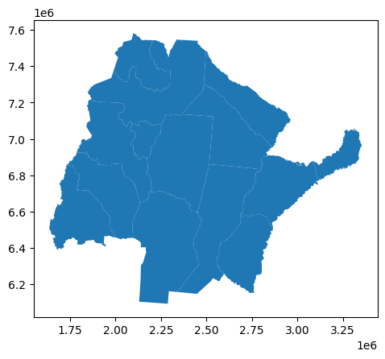

```python
prov_norte.plot()
```

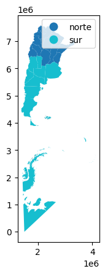

```python
provincias['region'] = 'norte'
provincias.loc[provincias.cx[:,:centroid_lat].index, 'region'] = 'sur'
provincias.plot(column='region', legend=True)
```

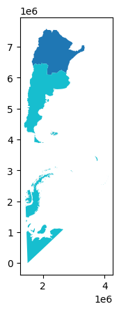

```python
unidos_norte=gpd.GeoDataFrame(index=[0],data={'ADM':'Norte'},
                 crs=provincias.crs,
                 geometry=[provincias[provincias.region=='norte'].union_all()])

unidos_sur=gpd.GeoDataFrame(index=[0],data={'ADM':'Sur'},
                 crs=provincias.crs,
                 geometry=[provincias[provincias.region=='sur'].union_all()])

unidos_norte_sur = gpd.pd.concat([unidos_norte, unidos_sur], ignore_index=True)
unidos_norte_sur.plot(column='ADM')
```

# DISSOLVE

```python
departamentos = gpd.read_file('https://github.com/LeonarddoCLS/Avance-2/raw/refs/heads/main/departamentos/departamentoPolygon.shp')
departamentos=departamentos.to_crs(5343)
```

```python
departamentos.head()
```

|  | gid | objeto | fna | gna | nam | in1 | fdc | sag | geometry |
| --- | --- | --- | --- | --- | --- | --- | --- | --- | --- |
| 0 | 38 | Departamento | Departamento Ojo de Agua | Departamento | Ojo de Agua | 86126 | Catastro Provinciales | IGN | POLYGON ((2276075.519 6782525.446, 2276264.373... |
| 1 | 39 | Departamento | Departamento Choya | Departamento | Choya | 86063 | Catastro Provinciales | IGN | POLYGON ((2225816.929 6862993.756, 2233663.751... |
| 2 | 65 | Departamento | Partido de Lezama | Partido | Lezama | 06466 | ARBA - Gerencia de Servicios Catastrales | IGN | POLYGON ((2784038.593 5957686.537, 2784665.484... |
| 3 | 102 | Departamento | Departamento Pilcaniyeu | Departamento | Pilcaniyeu | 62070 | IDE Rio Negro | IGN | POLYGON ((1692055.687 5583574.853, 1692055.041... |
| 4 | 118 | Departamento | Comuna 1 | Comuna | Comuna 1 | 02007 | Direc. de Catastro | IGN | POLYGON ((2753297.347 6088702.481, 2753313.38 ... |

```python
prov.head()
```

|  | gid | entidad | fna | gna | nam | in1 | fdc | sag | geometry |
| --- | --- | --- | --- | --- | --- | --- | --- | --- | --- |
| 0 | 1 | 0.0 | Ciudad Autónoma de Buenos Aires | Ciudad Autónoma | Ciudad Autónoma de Buenos Aires | 02 | Geografía | IGN | POLYGON ((2747652.364 6095235.901, 2747750.867... |
| 1 | 2 | 0.0 | Provincia de San Luis | Provincia | San Luis | 74 | Geografía | IGN | POLYGON ((1968211.939 6465396.366, 1968723.496... |
| 2 | 3 | 0.0 | Provincia de Santa Fe | Provincia | Santa Fe | 82 | Geografía | IGN | POLYGON ((2581134.497 6854846.203, 2584940.824... |
| 3 | 4 | 0.0 | Provincia de La Rioja | Provincia | La Rioja | 46 | Geografía | IGN | POLYGON ((1842859.281 6918841.663, 1842839.746... |
| 4 | 5 | 0.0 | Provincia de Catamarca | Provincia | Catamarca | 10 | Geografía | IGN | POLYGON ((1852441.661 7212670.781, 1852593.364... |

```python
departamentos.fdc.unique()
```

```
array(['Catastro Provinciales',
       'ARBA - Gerencia de Servicios Catastrales', 'IDE Rio Negro',
       'Direc. de Catastro', 'SCAR', 'IDE Salta',
       'Direc. Grl. de Inmuebles',
       'Servicio de Catastro e Información Territorial', 'IDE Mendoza',
       'IGN', 'Gerencia de Catastro Pcial.',
       'Direc. Pcial. de Catastro e Inf. Territorial',
       'Direc. de Geodesia y Catastro', 'Direc. Grl. de Catastro',
       'Ministerio de Ecología', 'IDE Tucuman',
       'Direc. Pcial. de Catastro y Cartografía',
       'ATER - Direc. de Catastro', 'IDE Chaco', 'IDE Cordoba',
       'IDE Catamarca', 'Catastro'], dtype=object)
```

```python
departamentos[~departamentos.is_valid]
```

|  | gid | objeto | fna | gna | nam | in1 | fdc | sag | geometry |
| --- | --- | --- | --- | --- | --- | --- | --- | --- | --- |
| 6 | 153 | Departamento | Departamento Antártida Argentina | Departamento | Antártida Argentina | 94028 | SCAR | IGN | MULTIPOLYGON (((2654168.387 1087347.883, 26349... |
| 510 | 525 | Departamento | Departamento Islas del Atlántico Sur | Departamento | Islas del Atlántico Sur | 94021 | IGN | IGN | MULTIPOLYGON (((2441787.736 4227942.649, 24417... |

```python
departamentos["geometry"] = departamentos["geometry"].buffer(0)
```

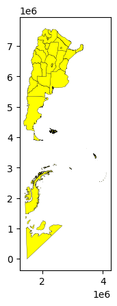

```python
departamentos.dissolve(by='fdc').plot(facecolor='yellow', edgecolor='black',linewidth=0.2)
```

```python
Argentina_fdc_diss=departamentos.dissolve(by='fdc')
```

```python
!pip install fiona
```

```python
import geopandas as gpd
from  fiona import listlayers

linkWorldMap="https://github.com/CienciaDeDatosEspacial/intro_geodataframe/raw/main/maps/worldMaps.gpkg"
indicators=gpd.read_file(linkWorldMap,layer='indicators')
```

```python
indicators.head()
```

|  | COUNTRY | Officialstatename | InternetccTLD | iso2 | iso3 | fragility_date | fragility | co2 | co2_date | region | ForestRev_gdp | ForestRev_date | fragility_Qt | fragility_Qt_jc5 | fragility_Qt_jc5_cat | geometry |
| --- | --- | --- | --- | --- | --- | --- | --- | --- | --- | --- | --- | --- | --- | --- | --- | --- |
| 0 | ANTIGUA AND BARBUDA | Antigua and Barbuda | .ag | AG | ATG | 2019 | 54.4 | 729000.0 | 2019 | CENTRAL AMERICA AND THE CARIBBEAN | 0.00 | 2018 | -0.530113 | 1 | 1_Good | MULTIPOLYGON (((-61.73889 17.54055, -61.75195 ... |
| 1 | AFGHANISTAN | The Islamic Republic of Afghanistan | .af | AF | AFG | 2019 | 105.0 | 7893000.0 | 2019 | SOUTH ASIA | 0.20 | 2018 | 1.827146 | 4 | 4_Poor | POLYGON ((61.27656 35.60725, 61.29638 35.62853... |
| 2 | ALGERIA | The People's Democratic Republic of Algeria | .dz | DZ | DZA | 2019 | 75.4 | 151633000.0 | 2019 | AFRICA | 0.10 | 2018 | 0.304520 | 3 | 3_Bad | POLYGON ((-5.15213 30.18047, -5.13917 30.19236... |
| 3 | AZERBAIJAN | The Republic of Azerbaijan | .az | AZ | AZE | 2019 | 73.2 | 35389000.0 | 2019 | MIDDLE EAST | 0.02 | 2018 | 0.233695 | 2 | 2_Middle | MULTIPOLYGON (((46.54037 38.87559, 46.49554 38... |
| 4 | ALBANIA | The Republic of Albania | .al | AL | ALB | 2019 | 58.9 | 3794000.0 | 2019 | EUROPE | 0.18 | 2018 | -0.424447 | 1 | 1_Good | POLYGON ((20.79192 40.43154, 20.78722 40.39472... |

```python
new_indicators=indicators.dissolve(
     by="region",
     aggfunc={
         "COUNTRY": "count",
         "fragility": ["median"],
         "co2": ["median"],
         "ForestRev_gdp": ["median"]
     },as_index=False,
 )
new_indicators
```

|  | region | geometry | (COUNTRY, count) | (fragility, median) | (co2, median) | (ForestRev_gdp, median) |
| --- | --- | --- | --- | --- | --- | --- |
| 0 | AFRICA | MULTIPOLYGON (((-2.92813 5.10022, -2.93222 5.1... | 51 | 87.40 | 4444000.0 | 2.470 |
| 1 | AUSTRALIA AND OCEANIA | MULTIPOLYGON (((-176.51779 -43.90778, -176.532... | 6 | 67.95 | 1023000.0 | 0.385 |
| 2 | CENTRAL AMERICA AND THE CARIBBEAN | MULTIPOLYGON (((-81.71556 7.44681, -81.71362 7... | 16 | 61.00 | 7873500.0 | 0.115 |
| 3 | CENTRAL ASIA | MULTIPOLYGON (((50.03472 45.04833, 50.0425 45.... | 6 | 75.20 | 106001000.0 | 0.005 |
| 4 | EAST AND SOUTHEAST ASIA | MULTIPOLYGON (((105.26361 -6.54472, 105.26138 ... | 15 | 70.40 | 238983000.0 | 0.180 |
| 5 | EUROPE | MULTIPOLYGON (((-18.13223 27.77264, -18.1132 2... | 39 | 40.50 | 38739000.0 | 0.150 |
| 6 | MIDDLE EAST | MULTIPOLYGON (((42.76819 14.06653, 42.7868 14.... | 16 | 72.60 | 68706500.0 | 0.000 |
| 7 | NORTH AMERICA | MULTIPOLYGON (((-155.211 20.00166, -155.18335 ... | 3 | 38.00 | 612084000.0 | 0.080 |
| 8 | SOUTH AMERICA | MULTIPOLYGON (((-74.93431 -51.85501, -74.93251... | 11 | 68.20 | 36051000.0 | 0.490 |
| 9 | SOUTH ASIA | MULTIPOLYGON (((73.10193 -0.58431, 73.09915 -0... | 8 | 84.35 | 15916000.0 | 0.120 |

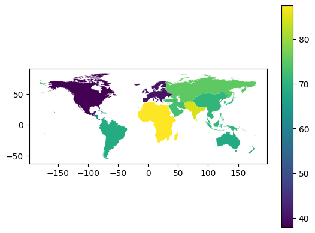

```python
new_indicators.plot(column=('fragility', 'median'), legend=True, cmap='viridis')
```

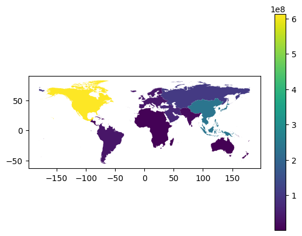

```python
new_indicators.plot(column=('co2', 'median'), legend=True, cmap='viridis')
```

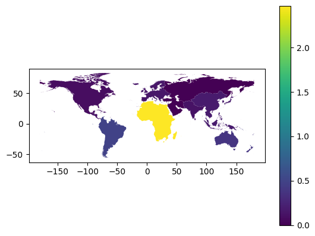

```python
new_indicators.plot(column=('ForestRev_gdp', 'median'), legend=True, cmap='viridis')
```

### Exercise 3

1. Select some points from your maps.
2. Create the convex hull for those points.
3. Turn the hull into a GDF.
4. Plot the hull on top of the country.

```python
aeropuertos=gpd.read_file('https://github.com/LeonarddoCLS/Avance-2/raw/refs/heads/main/aeropuertos/puntos_de_transporte_aereo_GB005Point.shp')
aeropuertos=aeropuertos.to_crs(5343)
```

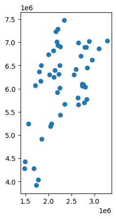

```python
aeropuertos_IGN=aeropuertos[aeropuertos.fdc=='IGN/ORSNA']
aeropuertos_IGN.plot()
# ME QUEDO CON LOS AEROPUERTOS REGISTRADOS POR  IGN
```

```python
aeropuertos_IGN.union_all().convex_hull
```

[figure not shown]

```python
aeropuertos_hull= gpd.GeoDataFrame(index=[0],
                                    crs=aeropuertos_IGN.crs,
                                    geometry=[aeropuertos_IGN.union_all().convex_hull])


aeropuertos_hull
```

|  | geometry |
| --- | --- |
| 0 | POLYGON ((1736873.028 3916366.243, 1484220.121... |

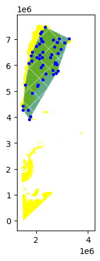

```python
base=prov.plot(facecolor='yellow')
aeropuertos_hull.plot(ax=base, alpha=0.4)
aeropuertos_hull.plot(ax=base,facecolor='green',
                       edgecolor='white',alpha=0.4,
                       hatch='X')
aeropuertos_IGN.plot(ax=base, marker='o', color='blue', markersize=8)
```

# Exercise 4

Apply two spatial overlays to your maps. If possible. If not, try the codes below.

### Spatial Overlay

```python
departamentos=departamentos.to_crs(5343)
```

```python
# the north
DepaN_argentina=departamentos.cx[:,centroid_lat:]
# the south
DepaS_argentina=departamentos.cx[:,:centroid_lat]
# the west
DepaW_argentina=departamentos.cx[:centroid_lon,:]
# the east
DepaE_argentina=departamentos.cx[centroid_lon:,:]
```

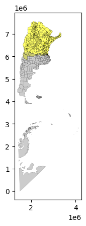

```python
base=DepaN_argentina.plot(facecolor='yellow', edgecolor='black',linewidth=0.2, alpha=0.6)
DepaS_argentina.plot(facecolor='grey', edgecolor='black',linewidth=0.2,ax=base, alpha=0.4)
```

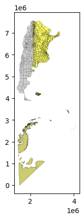

```python
base=DepaE_argentina.plot(facecolor='yellow', edgecolor='black',linewidth=0.2, alpha=0.6)
DepaW_argentina.plot(facecolor='grey', edgecolor='black',linewidth=0.2,ax=base, alpha=0.4)
```

### Intersection

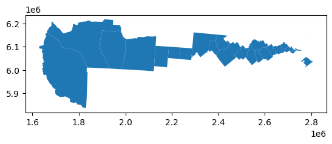

```python
depaNS_argentina=DepaN_argentina.overlay(DepaS_argentina, how="intersection",keep_geom_type=True, make_valid=True)
depaNS_argentina.plot()
```

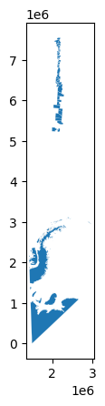

```python
depaWE_argentina=DepaW_argentina.overlay(DepaE_argentina, how="intersection",keep_geom_type=True)
depaWE_argentina.plot(edgecolor='white',linewidth=0.1)
```

### Union

```python
keep=['fna_1','gna_1','nam_1','geometry']
depaNS_argentina=depaNS_argentina.loc[:,keep]
depaWE_argentina=depaWE_argentina.loc[:,keep]
```

```python
depaNS_argentina.overlay(depaWE_argentina,how="union",keep_geom_type=True)
```

|  | fna_1_1 | gna_1_1 | nam_1_1 | fna_1_2 | gna_1_2 | nam_1_2 | geometry |
| --- | --- | --- | --- | --- | --- | --- | --- |
| 0 | Departamento Rancul | Departamento | Rancul | Departamento Rancul | Departamento | Rancul | POLYGON ((2180328.024 6100644.134, 2180587.411... |
| 1 | Comuna 1 | Comuna | Comuna 1 | NaN | NaN | NaN | POLYGON ((2753313.38 6088699.601, 2753333.834 ... |
| 2 | Departamento Realicó | Departamento | Realicó | NaN | NaN | NaN | POLYGON ((2235740.179 6082213.857, 2235304.088... |
| 3 | Departamento San Rafael | Departamento | San Rafael | NaN | NaN | NaN | POLYGON ((1946220.069 6194841.405, 1946222.513... |
| 4 | Partido de Lincoln | Partido | Lincoln | NaN | NaN | NaN | POLYGON ((2489326.755 6108996.521, 2489983.652... |
| ... | ... | ... | ... | ... | ... | ... | ... |
| 72 | NaN | NaN | NaN | Departamento Dr. Manuel Belgrano | Departamento | Dr. Manuel Belgrano | POLYGON ((2152488.909 7332264.103, 2152509.629... |
| 73 | NaN | NaN | NaN | Departamento Graneros | Departamento | Graneros | POLYGON ((2157991.138 6938532.378, 2157993.459... |
| 74 | NaN | NaN | NaN | Departamento Simoca | Departamento | Simoca | POLYGON ((2155102.825 6977734.368, 2155122.305... |
| 75 | NaN | NaN | NaN | Departamento Leales | Departamento | Leales | POLYGON ((2166918.969 7005177.525, 2166928.861... |
| 76 | NaN | NaN | NaN | Departamento Utracán | Departamento | Utracán | POLYGON ((2190410.926 5801413.002, 2190087.949... |

77 rows × 7 columns

```python
import pandas as pd

pd.concat([depaNS_argentina,depaWE_argentina],ignore_index=True)
```

|  | fna_1 | gna_1 | nam_1 | geometry |
| --- | --- | --- | --- | --- |
| 0 | Comuna 1 | Comuna | Comuna 1 | POLYGON ((2753313.38 6088699.601, 2753333.834 ... |
| 1 | Departamento Realicó | Departamento | Realicó | POLYGON ((2235754.902 6082380.797, 2235740.34 ... |
| 2 | Departamento San Rafael | Departamento | San Rafael | POLYGON ((1946220.069 6194841.405, 1946222.513... |
| 3 | Partido de Lincoln | Partido | Lincoln | POLYGON ((2489326.755 6108996.521, 2489983.652... |
| 4 | Partido de Moreno | Partido | Moreno | POLYGON ((2715092.629 6099911.817, 2715269.499... |
| ... | ... | ... | ... | ... |
| 73 | Departamento Dr. Manuel Belgrano | Departamento | Dr. Manuel Belgrano | POLYGON ((2152488.909 7332264.103, 2152509.629... |
| 74 | Departamento Graneros | Departamento | Graneros | POLYGON ((2157991.138 6938532.378, 2157993.459... |
| 75 | Departamento Simoca | Departamento | Simoca | POLYGON ((2155102.825 6977734.368, 2155122.305... |
| 76 | Departamento Leales | Departamento | Leales | POLYGON ((2166918.969 7005177.525, 2166928.861... |
| 77 | Departamento Utracán | Departamento | Utracán | POLYGON ((2190410.926 5801413.002, 2190087.949... |

78 rows × 4 columns

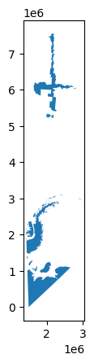

```python
depaNS_argentina.overlay(depaWE_argentina, how="union",keep_geom_type=True).dissolve().plot()
```

```python
depaMidArgentina=depaNS_argentina.overlay(depaWE_argentina, how="union",keep_geom_type=True).dissolve()
depaMidArgentina
```

|  | geometry | fna_1_1 | gna_1_1 | nam_1_1 | fna_1_2 | gna_1_2 | nam_1_2 |
| --- | --- | --- | --- | --- | --- | --- | --- |
| 0 | MULTIPOLYGON (((1465907.039 1392130.708, 14661... | Departamento Rancul | Departamento | Rancul | Departamento Rancul | Departamento | Rancul |

```python
depaMidArgentina['zone']='middles'
depaMidArgentina=depaMidArgentina.loc[:,['fna_1_1','zone','geometry']]
depaMidArgentina
```

|  | fna_1_1 | zone | geometry |
| --- | --- | --- | --- |
| 0 | Departamento Rancul | middles | MULTIPOLYGON (((1465907.039 1392130.708, 14661... |

### Difference

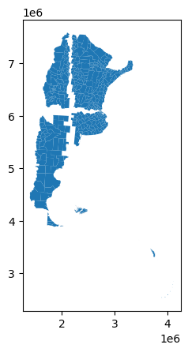

```python
departamentos.overlay(depaMidArgentina, how='difference').plot()
```

### Symmetric Difference

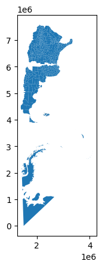

```python
DepaN_argentina.overlay(DepaS_argentina, how="symmetric_difference",keep_geom_type=True).plot()
```

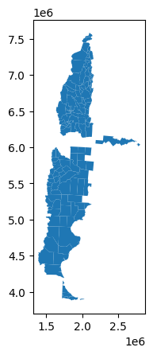

```python
DepaW_argentina.overlay(depaMidArgentina, how="symmetric_difference",keep_geom_type=False).plot()
```

### Validity of Geometry

```python
DepaS_argentina[~DepaS_argentina.is_valid]
```

|  | gid | objeto | fna | gna | nam | in1 | fdc | sag | geometry |
| --- | --- | --- | --- | --- | --- | --- | --- | --- | --- |

[figure not shown]

```python
DepaS_argentina[~DepaS_argentina.is_valid].plot()
```

```python
#from shapely.validation import explain_validity, make_valid

#explain_validity(DepaS_argentina[~DepaS_argentina.is_valid].geometry)
```

[output not shown]

```python
#DepaS_argentina['validity']=[x.split('[')[0] for x in DepaS_argentina.geometry.apply(lambda x: explain_validity(x))]
#DepaS_argentina['validity'].value_counts()
```

[output not shown]

```python
#DepaS_argentina.drop(columns=['validity'],inplace=True)

#DepaS_argentina_valid=DepaS_argentina.copy()

#DepaS_argentina_valid['geometry'] = [make_valid(row)  if not row.is_valid else row for row in DepaS_argentina_valid['geometry'] ]
#any invalid?
#DepaS_argentina_valid[~DepaS_argentina_valid.is_valid]
```

[output not shown]

```python
pd.Series([type(x) for x in DepaS_argentina_valid.geometry]).value_counts()
```

|  | count |
| --- | --- |
| <class 'shapely.geometry.polygon.Polygon'> | 184 |
| <class 'shapely.geometry.multipolygon.MultiPolygon'> | 13 |

**dtype:** int64

```python
DepaN_argentina_valid=DepaN_argentina.copy()
DepaE_argentina_valid=DepaE_argentina.copy()
DepaW_argentina_valid=DepaE_argentina.copy()

DepaN_argentina_valid['geometry'] = [make_valid(row)  if not row.is_valid else row for row in DepaN_argentina_valid['geometry'] ]
DepaE_argentina_valid['geometry'] = [make_valid(row)  if not row.is_valid else row for row in DepaE_argentina_valid['geometry'] ]
DepaW_argentina_valid['geometry'] = [make_valid(row)  if not row.is_valid else row for row in DepaW_argentina_valid['geometry'] ]
```

```python
DepaN_argentina_cleaned = DepaN_argentina_valid.copy()
DepaS_argentina_cleaned = DepaS_argentina_valid.copy()
DepaE_argentina_cleaned = DepaE_argentina_valid.copy()
DepaW_argentina_cleaned = DepaW_argentina_valid.copy()

# Apply buffer(0) to potentially fix remaining issues
DepaN_argentina_cleaned['geometry'] = DepaN_argentina_cleaned.geometry.buffer(0)
DepaS_argentina_cleaned['geometry'] = DepaS_argentina_cleaned.geometry.buffer(0)
DepaE_argentina_cleaned['geometry'] = DepaE_argentina_cleaned.geometry.buffer(0)
DepaW_argentina_cleaned['geometry'] = DepaW_argentina_cleaned.geometry.buffer(0)
```

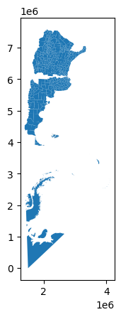

```python
DepaN_argentina_cleaned.overlay(DepaS_argentina_cleaned, how="symmetric_difference", keep_geom_type=True).plot()
```

[figure not shown]

```python
DepaE_argentina_cleaned.overlay(DepaW_argentina_cleaned, how="symmetric_difference", keep_geom_type=True).plot()
```